# Week 04 - Assignment 01

Steven Ponce

## Course: Introduction to the Tidyverse

Assignment Topic:

The goal of this assignment is to create a new data science project in preparation for analyzing data. The data analysis (not actually done here) would take the dataset for health care expenditures and consider the question: Is there a relationship between healthcare coverage and healthcare spending in the United States?

> If needed, run the following code: `install.packages('ProjectTemplate')`

## Load Library

```r
library('ProjectTemplate')
```

## Create new project template

To create new project, uncomment the code lines below

```r
# create.project(project.name = "week-04_assignment-01",
              # template = "minimal")
```

## Instructions:

1. Upload a screenshot of the project root directory displayed in the Files browser in RStudio. The project root directory is the highest level of the project hierarchy.

[figure not shown]

Figure 1: project root directory screenshot

2. Upload a screenshot that shows the location of the healthcare_datasets.zip file in the Files browser in RStudio.

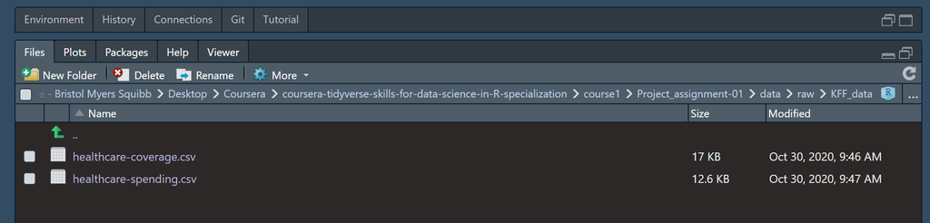

3. Upload a screenshot of the contents of the R Markdown file that you created to store the final report. For this you can open the R Markdown file in the RStudio editor.

[figure not shown]

Figure 3: R Markdown file screenshot

4. Upload a screenshot of the contents of the R script file that you created to contain the code for the exploratory analysis. For this you can open the R script file in the RStudio editor.

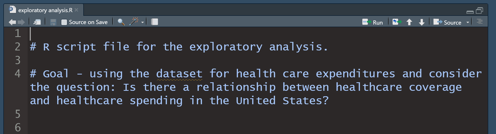

Figure 4: R script file screenshot